# Text Mining - Classification - Ham or Spam<a name=top></a>

In this notebook, you're going to use a SMS dataset (where texts have been classified as Ham/Spam) to build a model which can predict whether an incoming SMS is Spam or Ham based on its content.

## SECTIONS

1. Initialize the Environment
2. Import the Data
3. Explore the Data
4. Create the Corpus
5. Clean the Data
6. Create the DTM
7. Text Visualization
8. Training/Testing Data
9. Naive Bayes Classifier
10. Support Vector Machines
11. SVMs with PCA
12. Exercises

Back to top

## INITIALIZE THE ENVIRONMENT <a name=init></a>

```r
library(tm) # for text mining functions
library(qdap) # for some text processing functions
library(e1071) # for Naive Bayes and Support Vector Machines methods
library(dplyr) # for tidyverse processing
library(tidytext) # for tidyverse analysis
library(ggplot2) # for tidyverse plotting
library(psych) # for pairs.panels()
```

Back to top

## IMPORT THE DATA <a name=import></a>

We're going to use the classic Ham/Spam dataset, which has been stored to your `Data` folder.

```r
ham.spam <- read.csv("Data/SMSSpamCollection.csv", sep=",")
```

Back to top

## EXPLORE THE DATA <a name=explore></a>

The dataset consists of 5574 observations and 3 variables/features: SMS messages, length of the messages, and whether they are Ham (+) or Spam (-).

```r
ham.spam$Msg <- as.character(ham.spam$Msg) # ensure character for Msg
str(ham.spam)
```

```
'data.frame':	5574 obs. of  3 variables:
 $ SpamOrHam: Factor w/ 2 levels "ham","spam": 1 1 2 1 1 2 1 1 2 2 ...
 $ Msg      : chr  "Go until jurong point, crazy.. Available only in bugis n great world la e buffet... Cine there got amore wat..." "Ok lar... Joking wif u oni..." "Free entry in 2 a wkly comp to win FA Cup final tkts 21st May 2005. Text FA to 87121 to receive entry question(std txt rate)T&C"| __tr…
 $ length   : int  111 29 155 49 61 148 77 160 158 154 ...
```

Let's print a few SMS to get a better idea.

```r
ham.spam$Msg[12]
ham.spam$Msg[4444]
```

'SIX chances to win CASH! From 100 to 20,000 pounds txt> CSH11 and send to 87575. Cost 150p/day, 6days, 16+ TsandCs apply Reply HL 4 info'

'Dear i am not denying your words please'

What about the distribution of Ham/Spam?

```r
table(ham.spam$SpamOrHam)
prop.table(table(ham.spam$SpamOrHam))
```

```
 ham spam
4827  747
```

```
      ham      spam
0.8659849 0.1340151
```

Before diving right into text analysis, is there anything we can say about the SMS categories just by looking at their length?

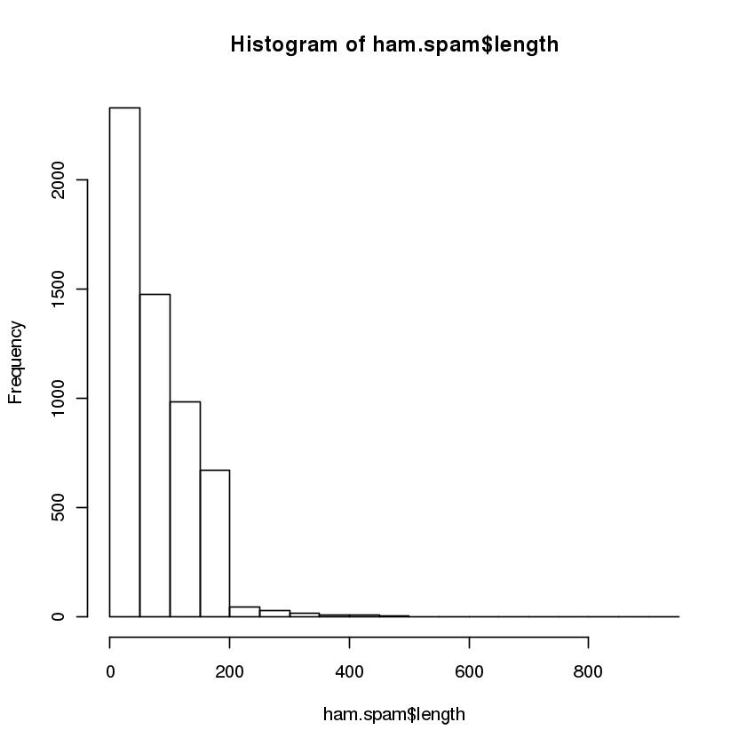

```r
hist(ham.spam$length)
```

`ggplot2` can help us make nicer looking charts, from which we can gain some insights about SMS spam messages.

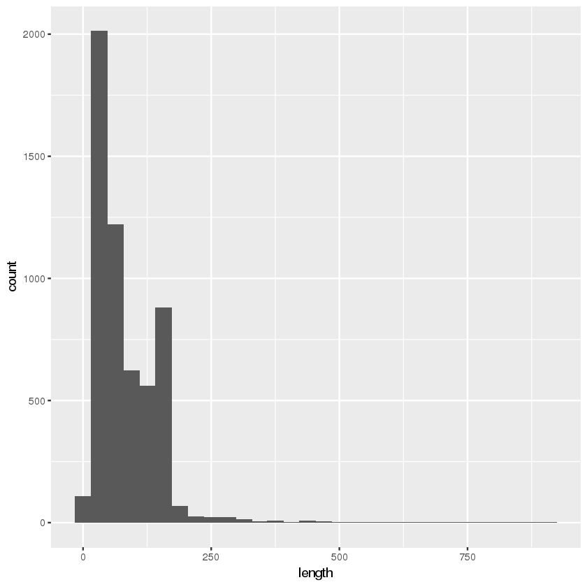

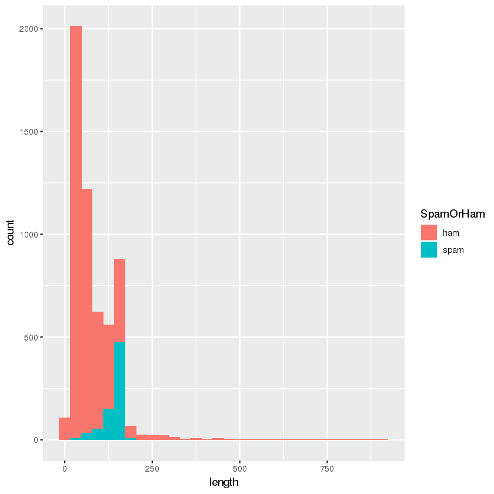

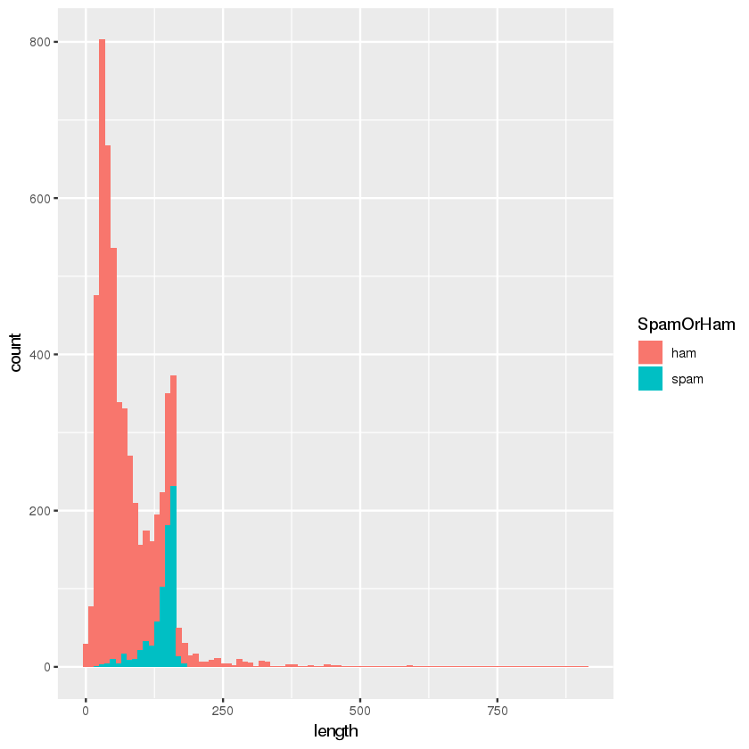

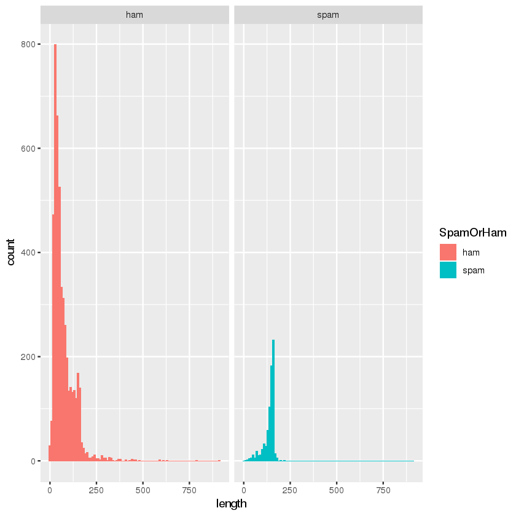

```r
ggplot(ham.spam, aes(length)) + geom_histogram()
ggplot(ham.spam, aes(length, fill = SpamOrHam)) + geom_histogram()
ggplot(ham.spam, aes(length, fill = SpamOrHam)) + geom_histogram(binwidth=10)
ggplot(ham.spam, aes(length, fill = SpamOrHam)) + geom_histogram(binwidth=10) + facet_wrap(~SpamOrHam)
```

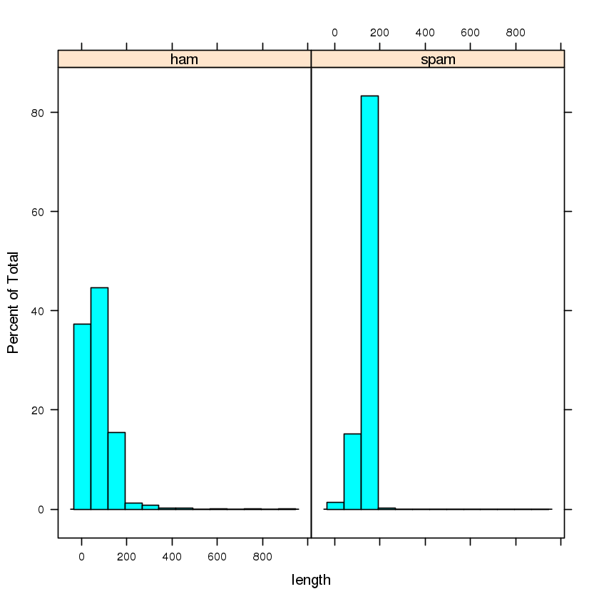

```r
library(lattice)
histogram(~length | SpamOrHam, data=ham.spam)
```

Does anything jump at you?

Back to top

## CREATE THE CORPUS<a name=corpus></a>

In order to do text classification, we first need to prepare a document-term matrix (or a term-document matrix, it depends on the context).

The `tm` functionality that you've seen in the notebook TMNLP 01 does just the trick.

```r
SMS.corpus <- Corpus(VectorSource(ham.spam$Msg))
print(SMS.corpus)
inspect(SMS.corpus[1:4]) # let's take a quick peek to make sure everything is as it should be
```

```
<<SimpleCorpus>>
Metadata:  corpus specific: 1, document level (indexed): 0
Content:  documents: 5574
<<SimpleCorpus>>
Metadata:  corpus specific: 1, document level (indexed): 0
Content:  documents: 4

[1] Go until jurong point, crazy.. Available only in bugis n great world la e buffet... Cine there got amore wat...
[2] Ok lar... Joking wif u oni...
[3] Free entry in 2 a wkly comp to win FA Cup final tkts 21st May 2005. Text FA to 87121 to receive entry question(std txt rate)T&C's apply 08452810075over18's
[4] U dun say so early hor... U c already then say...
```

Back to top

## CLEAN THE DATA<a name=clean></a>

As is **almost always** the case, the next step is to clean the corpus. Note that the order in which the cleaning steps are performed may affect the final form of the cleaned corpus.

In the case of spam detection, can you think of some reasons why you might not want to be too drastic with the cleaning stage?

```r
# Function to clean the corpus
clean_corpus <- function(corpus){
  corpus <- tm_map(corpus, content_transformer(replace_abbreviation))
  corpus <- tm_map(corpus, removePunctuation)
  corpus <- tm_map(corpus, removeNumbers)
  corpus <- tm_map(corpus, stemDocument)
  corpus <- tm_map(corpus, content_transformer(tolower))
  corpus <- tm_map(corpus, stripWhitespace)
  corpus <- tm_map(corpus, removeWords, c(stopwords("en")))
    return(corpus)
}

SMS.corpus.clean <- clean_corpus(SMS.corpus)
```

```r
inspect(SMS.corpus.clean[1:4])
```

```
<<SimpleCorpus>>
Metadata:  corpus specific: 1, document level (indexed): 0
Content:  documents: 4

[1] go  jurong point crazi availabl onli  bugi n great world la e buffet cine  got amor wat
[2] ok lar joke wif u oni
[3] free entri   wkli comp  win fa cup final tkts st may text fa   receiv entri questionstd txt ratetc appli
[4] u dun say  earli hor u c alreadi  say
```

Back to top

## CREATE DTM<a name=dtm></a>

We want to classify **documents**, so we need a DTM (instead of a TDM) representation of the text dataset on which to apply classifiers.

```r
SMS.DTM <- DocumentTermMatrix(SMS.corpus.clean)
inspect(SMS.DTM[1:20,20:30])
```

```
<<DocumentTermMatrix (documents: 20, terms: 11)>>
Non-/sparse entries: 17/203
Sparsity           : 92%
Maximal term length: 11
Weighting          : term frequency (tf)
Sample             :
    Terms
Docs cup entri final free may questionstd ratetc receiv text txt
  1    0     0     0    0   0           0      0      0    0   0
  10   0     0     0    2   0           0      0      0    0   0
  12   0     0     0    0   0           0      0      0    0   1
  13   0     0     0    1   0           0      0      0    0   1
  16   0     0     0    0   0           0      0      0    0   1
  2    0     0     0    0   0           0      0      0    0   0
  20   0     0     0    0   0           0      0      0    0   1
  3    1     2     1    1   1           1      1      1    1   1
  4    0     0     0    0   0           0      0      0    0   0
  5    0     0     0    0   0           0      0      0    0   0
```

Back to top

## TEXT VISUALIZATION<a name=viz></a>

Before we start with classification proper, let us visualize the frequent terms of both the Spam and the Ham cases.

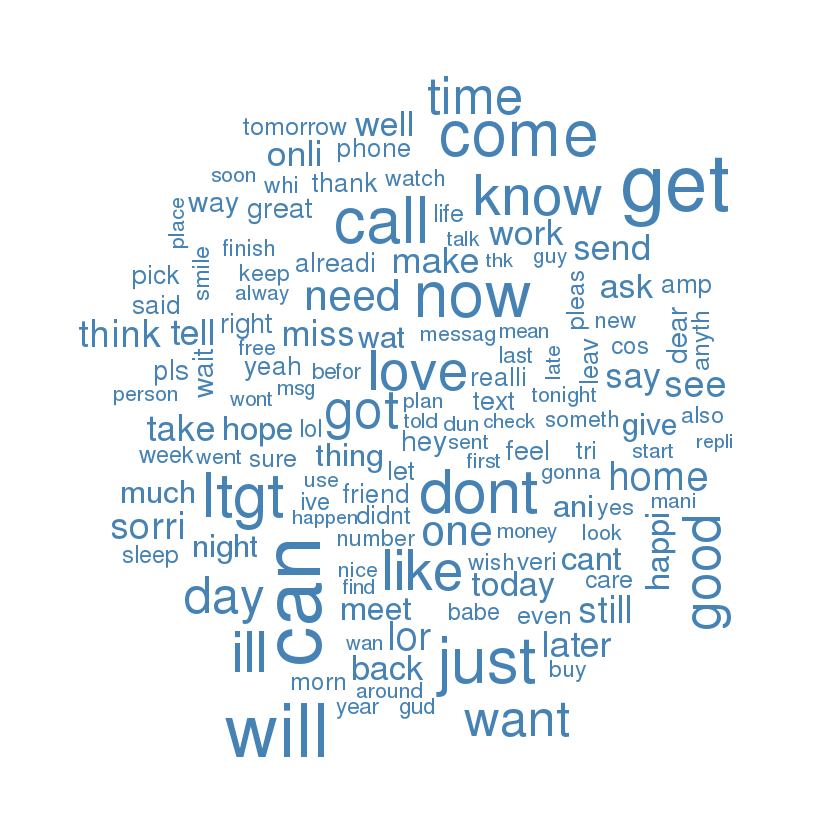

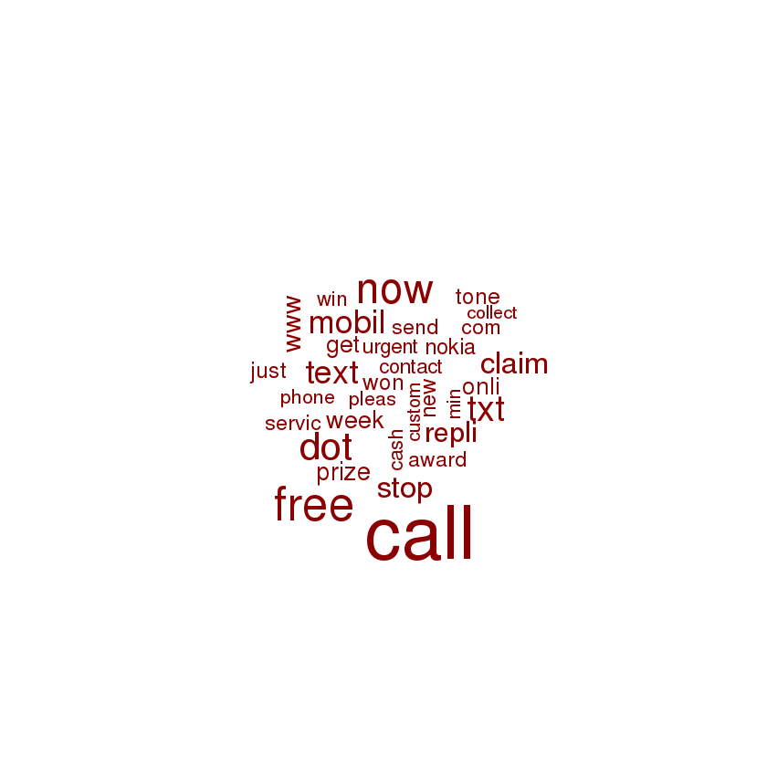

```r
spam.cloud <- which(ham.spam$SpamOrHam == "spam")
ham.cloud <- which(ham.spam$SpamOrHam == "ham")
library(wordcloud)
wordcloud(SMS.corpus.clean[ham.cloud],min.freq=50,colors="steelblue")
wordcloud(SMS.corpus.clean[spam.cloud],min.freq=50,colors="darkred")
```

We can also identify document-specific high-information terms using the tf-idf weighting.

| SpamOrHam | word | n | tf | idf | tf_idf |
| --- | --- | --- | --- | --- | --- |
| spam | claim | 113 | 0.006113065 | 0.6931472 | 0.0042372535 |
| spam | prize | 92 | 0.004977008 | 0.6931472 | 0.0034497993 |
| ham | gt | 318 | 0.004589738 | 0.6931472 | 0.0031813640 |
| ham | lt | 316 | 0.004560872 | 0.6931472 | 0.0031613554 |
| spam | won | 73 | 0.003949148 | 0.6931472 | 0.0027373408 |
| spam | 150p | 71 | 0.003840952 | 0.6931472 | 0.0026623451 |
| spam | tone | 59 | 0.003191777 | 0.6931472 | 0.0022123713 |
| ham | he | 191 | 0.002756729 | 0.6931472 | 0.0019108192 |
| spam | guaranteed | 50 | 0.002704896 | 0.6931472 | 0.0018748909 |
| spam | 18 | 49 | 0.002650798 | 0.6931472 | 0.0018373931 |
| ham | ü | 170 | 0.002453634 | 0.6931472 | 0.0017007292 |
| ham | i'll | 168 | 0.002424767 | 0.6931472 | 0.0016807206 |
| spam | cs | 44 | 0.002380308 | 0.6931472 | 0.0016499040 |
| ham | lor | 162 | 0.002338168 | 0.6931472 | 0.0016206949 |
| spam | 500 | 43 | 0.002326210 | 0.6931472 | 0.0016124062 |
| spam | 1000 | 41 | 0.002218015 | 0.6931472 | 0.0015374106 |
| ham | da | 149 | 0.002150538 | 0.6931472 | 0.0014906391 |
| spam | awarded | 38 | 0.002055721 | 0.6931472 | 0.0014249171 |
| ham | later | 135 | 0.001948474 | 0.6931472 | 0.0013505790 |
| spam | 1.50 | 36 | 0.001947525 | 0.6931472 | 0.0013499215 |
| ham | she | 132 | 0.001905174 | 0.6931472 | 0.0013205662 |
| spam | 150ppm | 34 | 0.001839329 | 0.6931472 | 0.0012749258 |
| spam | ringtone | 32 | 0.001731133 | 0.6931472 | 0.0011999302 |
| spam | collection | 26 | 0.001406546 | 0.6931472 | 0.0009749433 |
| spam | entry | 26 | 0.001406546 | 0.6931472 | 0.0009749433 |
| spam | tones | 26 | 0.001406546 | 0.6931472 | 0.0009749433 |
| ham | ask | 89 | 0.001284549 | 0.6931472 | 0.0008903817 |
| ham | said | 89 | 0.001284549 | 0.6931472 | 0.0008903817 |
| ham | amp | 88 | 0.001270116 | 0.6931472 | 0.0008803775 |
| ham | doing | 88 | 0.001270116 | 0.6931472 | 0.0008803775 |
| ham | morning | 78 | 0.001125785 | 0.6931472 | 0.0007803346 |
| ham | cos | 76 | 0.001096919 | 0.6931472 | 0.0007603260 |

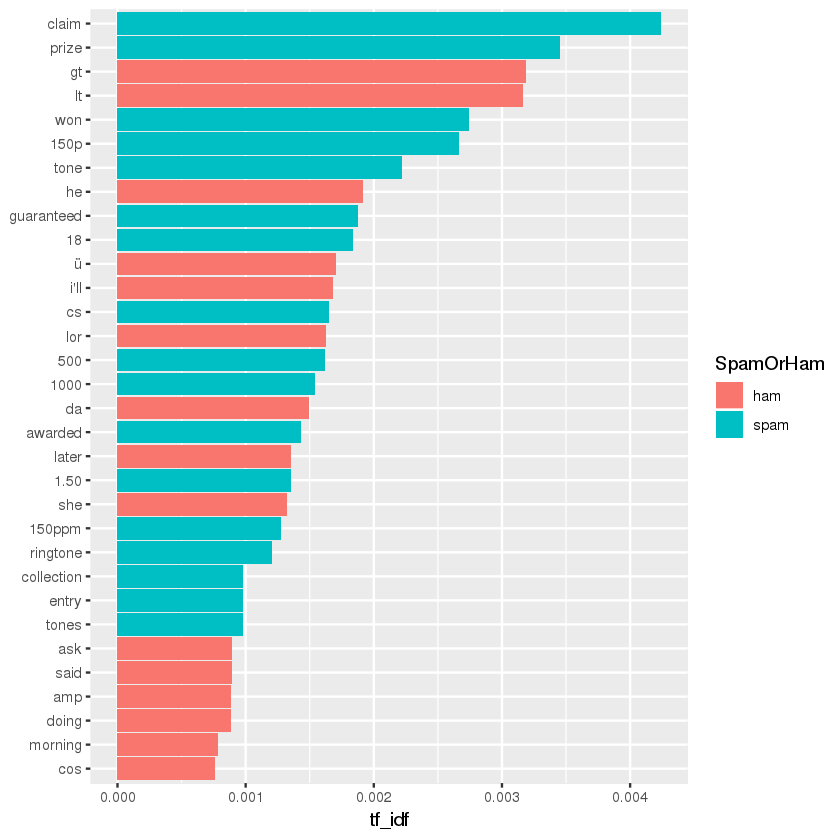

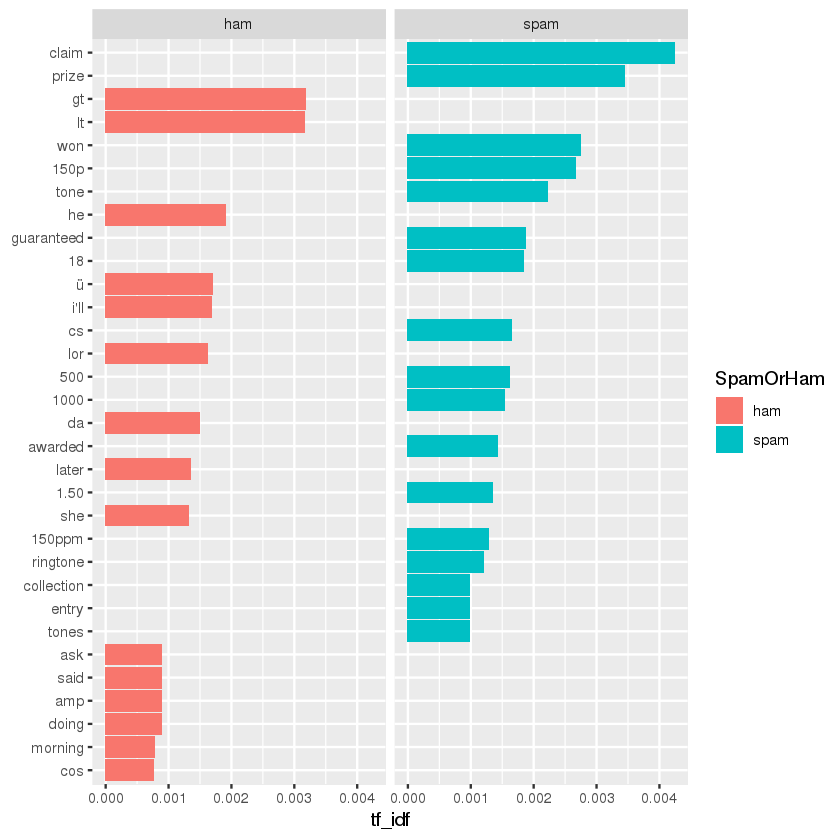

```r
SMS_words <- ham.spam %>%
  unnest_tokens(word,Msg) %>%
  count(SpamOrHam,word, sort=TRUE) %>%
  ungroup()

SMS_distinctive <- SMS_words %>%
  bind_tf_idf(word,SpamOrHam,n) %>%
  arrange(desc(tf_idf)) %>%
  mutate(word = factor(word, levels = rev(unique(word)))) %>%
  group_by(SpamOrHam) %>%
  top_n(15,tf_idf) %>%
  ungroup()

SMS_distinctive

ggplot(SMS_distinctive, aes(word,tf_idf, fill = SpamOrHam)) +
  geom_col(show.legend=TRUE) +
  labs(x=NULL, y="tf_idf") +
  #facet_wrap(~SpamOrHam) +
  coord_flip()

ggplot(SMS_distinctive, aes(word,tf_idf, fill = SpamOrHam)) +
  geom_col(show.legend=TRUE) +
  labs(x=NULL, y="tf_idf") +
  facet_wrap(~SpamOrHam) +
  coord_flip()
```

Back to top

## TRAINING/TESTING DATA<a name=ttd></a>

Classifiers need to be trained on a subset of the data and tested/evaluated on the complement to avoid **overfitting** the model. There's no steadfast rule, but a 70%/30% split is often applied.

```r
ind = sample(1:nrow(ham.spam), size=0.7*nrow(ham.spam))

ham.spam.train.labels <- ham.spam[ind,]$SpamOrHam
ham.spam.test.labels <- ham.spam[-ind,]$SpamOrHam
```

We can verify that the training/testing sets are representative (in terms of the target labels).

```r
prop.table(table(ham.spam.train.labels))
prop.table(table(ham.spam.test.labels))
prop.table(table(ham.spam$SpamOrHam))
```

```
ham.spam.train.labels
      ham      spam
0.8664445 0.1335555
```

```
ham.spam.test.labels
      ham      spam
0.8649133 0.1350867
```

```
      ham      spam
0.8659849 0.1340151
```

Let's translate the training/testing messages in terms of DTMs and corpora.

```r
SMS.DTM.train <- SMS.DTM[ind,]
SMS.DTM.test <- SMS.DTM[-ind,]
```

```r
SMS.corpus.clean.train <- SMS.corpus.clean[ind]
SMS.corpus.clean.test <- SMS.corpus.clean[-ind]
```

We also need to select the **features** (in this case, terms) to include in the model (otherwise, there'd be too much information to consider). We can use the list of all terms that appear at least 10 times in the training messages, for instance (another approach could be to remove sparse terms).

```r
spam.train = subset(ham.spam[ind,], SpamOrHam == "spam")
ham.train = subset(ham.spam[ind,], SpamOrHam == "ham")
```

```r
Freq.Terms <- findFreqTerms(SMS.DTM.train,10)
length(Freq.Terms)
Freq.Terms[1:100]
```

614

1. 'crazi'

2. 'got'

3. 'great'

4. 'onli'

5. 'point'

6. 'wat'

7. 'world'

8. 'joke'

9. 'lar'

10. 'wif'

11. 'appli'

12. 'entri'

13. 'final'

14. 'free'

15. 'may'

16. 'receiv'

17. 'text'

18. 'txt'

19. 'win'

20. 'wkli'

21. 'alreadi'

22. 'dun'

23. 'earli'

24. 'say'

25. 'around'

26. 'dont'

27. 'goe'

28. 'live'

29. 'think'

30. 'though'

31. 'back'

32. 'freemsg'

33. 'fun'

34. 'hey'

35. 'like'

36. 'now'

37. 'send'

38. 'still'

39. 'week'

40. 'word'

41. 'xxx'

42. 'brother'

43. 'even'

44. 'speak'

45. 'treat'

46. 'caller'

47. 'copi'

48. 'friend'

49. 'per'

50. 'press'

51. 'set'

52. 'call'

53. 'claim'

54. 'code'

55. 'custom'

56. 'hour'

57. 'network'

58. 'prize'

59. 'select'

60. 'valid'

61. 'winner'

62. 'camera'

63. 'colour'

64. 'latest'

65. 'mobil'

66. 'month'

67. 'update'

68. 'enough'

69. 'gonna'

70. 'home'

71. 'ive'

72. 'soon'

73. 'stuff'

74. 'talk'

75. 'today'

76. 'tonight'

77. 'want'

78. 'cash'

79. 'chanc'

80. 'cost'

81. 'day'

82. 'info'

83. 'pound'

84. 'repli'

85. 'dot'

86. 'pobox'

87. 'urgent'

88. 'won'

89. 'www'

90. 'help'

91. 'right'

92. 'search'

93. 'take'

94. 'thank'

95. 'time'

96. 'will'

97. 'wonder'

98. 'wont'

99. 'date'

100. 'com'

```r
SMS.DTM.Freq.Terms.train <- SMS.DTM.train[,Freq.Terms]
SMS.DTM.Freq.Terms.test <- SMS.DTM.test[,Freq.Terms]
head(SMS.DTM.Freq.Terms.train)
head(SMS.DTM.Freq.Terms.test)
```

[output not shown]

We also need to categorize the features so that the data can be fed into a Naive Bayes classifier. Here, the absence of a frequent term in a SMS message is denoted by `"No"`, while it's presence is denoted by `"Yes"`.

```r
yes.no <- function(x){
    y <- ifelse(x>0,1,0)
    y <- factor(y,levels=c(0,1),labels=c("No","Yes"))
    return(y)
}
```

```r
SMS.train <- apply(SMS.DTM.Freq.Terms.train,2,yes.no)
SMS.test <- apply(SMS.DTM.Freq.Terms.test,2,yes.no)
head(SMS.train)
head(SMS.test)
```

|  | crazi | got | great | onli | point | wat | world | joke | lar | wif | ⋯ | grin | onlin | luck | chennai | parent | fren | marri | alon | auction | lei |
| --- | --- | --- | --- | --- | --- | --- | --- | --- | --- | --- | --- | --- | --- | --- | --- | --- | --- | --- | --- | --- | --- |
| 3151 | No | No | No | No | No | No | No | No | No | No | ⋯ | No | No | No | No | No | No | No | No | No | No |
| 1572 | No | Yes | No | No | No | No | No | No | No | No | ⋯ | No | No | No | Yes | No | No | No | No | No | No |
| 3200 | No | No | No | No | No | Yes | No | No | No | No | ⋯ | No | No | No | No | No | No | No | No | No | No |
| 1805 | No | No | No | No | No | No | No | No | No | No | ⋯ | No | No | No | No | No | No | No | No | No | No |
| 1201 | No | No | No | No | No | No | No | No | No | No | ⋯ | No | No | No | No | No | No | No | No | No | No |
| 534 | No | No | No | No | No | No | No | No | No | No | ⋯ | No | No | No | No | No | No | No | No | No | No |

|  | crazi | got | great | onli | point | wat | world | joke | lar | wif | ⋯ | grin | onlin | luck | chennai | parent | fren | marri | alon | auction | lei |
| --- | --- | --- | --- | --- | --- | --- | --- | --- | --- | --- | --- | --- | --- | --- | --- | --- | --- | --- | --- | --- | --- |
| 3 | No | No | No | No | No | No | No | No | No | No | ⋯ | No | No | No | No | No | No | No | No | No | No |
| 7 | No | No | No | No | No | No | No | No | No | No | ⋯ | No | No | No | No | No | No | No | No | No | No |
| 9 | No | No | No | Yes | No | No | No | No | No | No | ⋯ | No | No | No | No | No | No | No | No | No | No |
| 11 | No | No | No | No | No | No | No | No | No | No | ⋯ | No | No | No | No | No | No | No | No | No | No |
| 13 | No | No | No | No | No | No | No | No | No | No | ⋯ | No | No | No | No | No | No | No | No | No | No |
| 14 | No | No | No | No | No | No | No | No | No | No | ⋯ | No | No | No | No | No | No | No | No | No | No |

Back to top

## NAIVE BAYES CLASSIFIER<a name=nbc></a>

We can now apply the `naiveBayes` function (from library `e1071`). Notice the syntax: we apply `naiveBayes` to the training data `SMS.train` (see above), and the target variable is ham/spam labels in the training subset (`ham.spam.train.labels`). The `laplace=1` option instructs `naiveBayes` to look "a little bit harder" into the data, while the `CV=10` option selects 10 cross-validations.

```r
SMS.classifier.NB <- naiveBayes(SMS.train,ham.spam.train.labels,laplace=1,CV=10) # laplace=1: dig down
class(SMS.classifier.NB)
summary(SMS.classifier.NB)
attributes(SMS.classifier.NB)
```

'naiveBayes'

```
        Length Class  Mode
apriori   2    table  numeric
tables  614    -none- list
levels    2    -none- character
call      5    -none- call
```

**$names**

1. 'apriori'

2. 'tables'

3. 'levels'

4. 'call'

**$class**

'naiveBayes'

Here are some of the model's attributes.

```r
SMS.classifier.NB$apriori
SMS.classifier.NB$tables
SMS.classifier.NB$levels
```

```
ham.spam.train.labels
 ham spam
3380  521
```

```
$crazi
                     crazi
ham.spam.train.labels          No         Yes
                 ham  0.997930219 0.002069781
                 spam 0.992351816 0.007648184

$got
                     got
ham.spam.train.labels         No        Yes
                 ham  0.95564755 0.04435245
                 spam 0.98661568 0.01338432

$great
                     great
ham.spam.train.labels         No        Yes
                 ham  0.98196334 0.01803666
                 spam 0.98087954 0.01912046

$onli
                     onli
ham.spam.train.labels         No        Yes
                 ham  0.97457126 0.02542874
                 spam 0.88718929 0.11281071

$point
                     point
ham.spam.train.labels          No         Yes
                 ham  0.995564755 0.004435245
                 spam 0.971319312 0.028680688

$wat
                     wat
ham.spam.train.labels          No         Yes
                 ham  0.977528090 0.022471910
                 spam 0.996175908 0.003824092

$world
                     world
ham.spam.train.labels          No         Yes
                 ham  0.993199290 0.006800710
```

[output cut: 3628 more lines]

```
ham.spam.train.labels          No         Yes
                 ham  0.996451804 0.003548196
                 spam 0.996175908 0.003824092

$auction
                     auction
ham.spam.train.labels           No          Yes
                 ham  0.9994086339 0.0005913661
                 spam 0.9847036329 0.0152963671

$lei
                     lei
ham.spam.train.labels          No         Yes
                 ham  0.995564755 0.004435245
                 spam 0.998087954 0.001912046
```

1. 'ham'

2. 'spam'

We can now feed the testing data (`SMS.test`) into the model (`SMS.classifier.NB`) with the help of the `predict` function.

```r
SMS.test.pred.NB <- predict(SMS.classifier.NB, newdata=SMS.test)
```

A confusion table is shown below. Not bad!

```r
table(SMS.test.pred.NB,ham.spam.test.labels)
```

```
                ham.spam.test.labels
SMS.test.pred.NB  ham spam
            ham  1444   26
            spam    3  200
```

```r
prop.table(table(SMS.test.pred.NB,ham.spam.test.labels))

# is there a difference in the representations of mislabeled and sucessfully labeled test messages?
Missed=SMS.test[which(SMS.test.pred.NB!=ham.spam.test.labels),]
Succesful=SMS.test[which(SMS.test.pred.NB==ham.spam.test.labels),]
table(Missed)
table(Succesful)

# original SMS of mislabeled and succesfully test data
head(ham.spam[as.numeric(rownames(Missed)),]$Msg)
head(ham.spam[as.numeric(rownames(Succesful)),]$Msg)
```

```
                ham.spam.test.labels
SMS.test.pred.NB         ham        spam
            ham  0.863120143 0.015540944
            spam 0.001793186 0.119545726
```

```
Missed
   No   Yes
17653   153
```

```
Succesful
     No     Yes
1000706    8710
```

1. 'England v Macedonia - dont miss the goals/team news. Txt ur national team to 87077 eg ENGLAND to 87077 Try:WALES, SCOTLAND 4txt/ú1.20 POBOXox36504W45WQ 16+'

2. 'U 447801259231 have a secret admirer who is looking 2 make contact with U-find out who they R*reveal who thinks UR so special-call on 09058094597'

3. 'SMS. ac Blind Date 4U!: Rodds1 is 21/m from Aberdeen, United Kingdom. Check Him out http://img. sms. ac/W/icmb3cktz8r7!-4 no Blind Dates send HIDE'

4. 'XCLUSIVE@CLUBSAISAI 2MOROW 28/5 SOIREE SPECIALE ZOUK WITH NICHOLS FROM PARIS.FREE ROSES 2 ALL LADIES !!! info: 07946746291/07880867867 '

5. 'Its a valentine game. . . Send dis msg to all ur friends. .. If 5 answers r d same then someone really loves u. Ques- which colour suits me the best?rply me'

6. 'Hi I\'m sue. I am 20 years old and work as a lapdancer. I love sex. Text me live - I\'m i my bedroom now. text SUE to 89555. By TextOperator G2 1DA 150ppmsg 18+'

1. 'Free entry in 2 a wkly comp to win FA Cup final tkts 21st May 2005. Text FA to 87121 to receive entry question(std txt rate)T&C\'s apply 08452810075over18\'s'

2. 'Even my brother is not like to speak with me. They treat me like aids patent.'

3. 'WINNER!! As a valued network customer you have been selected to receivea £900 prize reward! To claim call 09061701461. Claim code KL341. Valid 12 hours only.'

4. 'I\'m gonna be home soon and i don\'t want to talk about this stuff anymore tonight, k? I\'ve cried enough today.'

5. 'URGENT! You have won a 1 week FREE membership in our £100,000 Prize Jackpot! Txt the word: CLAIM to No: 81010 T&C www.dbuk.net LCCLTD POBOX 4403LDNW1A7RW18'

6. 'I\'ve been searching for the right words to thank you for this breather. I promise i wont take your help for granted and will fulfil my promise. You have been wonderful and a blessing at all times.'

What parameters can be modified? How is the model **tuned**?

Back to top

## SUPPORT VECTOR MACHINES<a name=svm></a>

We can use other classifiers - `e1071` also implements `svm` (**support vector machines**). The principle is the same, although we do not need to first categorize the features (as in NBC).

Can you figure out the syntax? Ignore the parameter `type` for now.

The `cost` is related to the price of allowing misclassifications: higher cost values attempt to minimize such misclassifications, but the resulting model tends to lead to overfitting (a littel flexibility in re: misclassfications is a good thing in the long run).

There is some evidence to suggest that the choice of the `"linear"` kernel is preferable when dealing with text data (as opposed to `gaussian` for some numerical data).

The steps proceeds as in the NBC case (although we demonstrate the `classAgreement` functionality for evaluation the classifier). You can get details on the method by querying the help files.

```r
SMS.classifier.SVM <- svm(ham.spam.train.labels ~., data=as.data.frame(as.matrix(SMS.DTM.Freq.Terms.train)),type="C-classification",cost=10,kernel="linear")
class(SMS.classifier.SVM)
summary(SMS.classifier.SVM)
attributes(SMS.classifier.SVM)
```

1. 'svm.formula'

2. 'svm'

```
Call:
svm(formula = ham.spam.train.labels ~ ., data = as.data.frame(as.matrix(SMS.DTM.Freq.Terms.train)),
    type = "C-classification", cost = 10, kernel = "linear")


Parameters:
   SVM-Type:  C-classification
 SVM-Kernel:  linear
       cost:  10
      gamma:  0.001628664

Number of Support Vectors:  424

 ( 299 125 )


Number of Classes:  2

Levels:
 ham spam
```

**$names**

1. 'call'

2. 'type'

3. 'kernel'

4. 'cost'

5. 'degree'

6. 'gamma'

7. 'coef0'

8. 'nu'

9. 'epsilon'

10. 'sparse'

11. 'scaled'

12. 'x.scale'

13. 'y.scale'

14. 'nclasses'

15. 'levels'

16. 'tot.nSV'

17. 'nSV'

18. 'labels'

19. 'SV'

20. 'index'

21. 'rho'

22. 'compprob'

23. 'probA'

24. 'probB'

25. 'sigma'

26. 'coefs'

27. 'na.action'

28. 'fitted'

29. 'decision.values'

30. 'terms'

**$class**

1. 'svm.formula'

2. 'svm'

**ham**

1430

**spam**

243

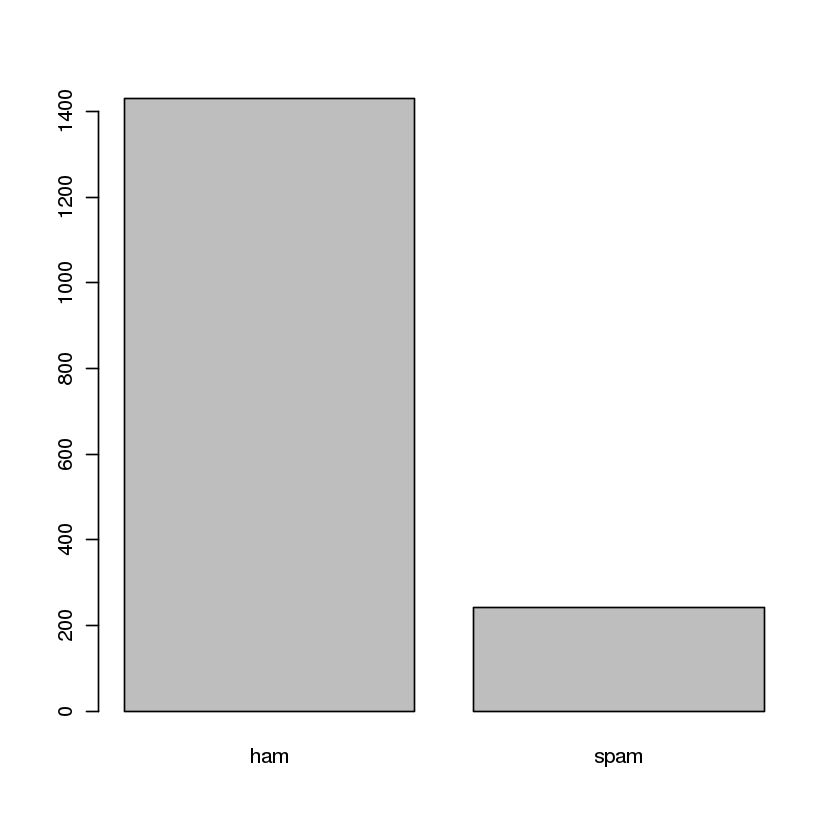

```r
SMS.test.pred.SVM <- predict(SMS.classifier.SVM,as.data.frame(as.matrix(SMS.DTM.Freq.Terms.test)))
summary(SMS.test.pred.SVM)   # provide a summary of the predicted values
plot(SMS.test.pred.SVM)   # ... and a plot
```

```r
table(SMS.test.pred.SVM,ham.spam.test.labels)
```

```
                 ham.spam.test.labels
SMS.test.pred.SVM  ham spam
             ham  1401   29
             spam   46  197
```

```r
(confusion.matrix = table(pred = SMS.test.pred.SVM, true = ham.spam.test.labels))
classAgreement(confusion.matrix,match.names=TRUE)    # some metrics to determine how good the classifier is at predicting data
```

```
      true
pred    ham spam
  ham  1401   29
  spam   46  197
```

**$diag**

0.955170352659892

**$kappa**

0.814056292151316

**$rand**

0.914308879845105

**$crand**

0.765924533730063

```r
?classAgreement
```

Back to top

## SVMs WITH PCA<a name=pca></a>

Finally, we re-visit the SVM model by first reducing the DTM data to its first 4 principal component (mostly to introduce you a more complete classification workflow).

1. PCA on training data
2. Formulas for going back and forth between original data and rotated data
3. Set in a data frame
4. Scatter plot
5. Express the test data in the training PCA universe
6. Tune the SVM model (run some preliminary code to determine the optimal choice of model parameters)
7. Train the SVM model
8. Fit the SVM model to testing data
9. Evaluate

```r
# PCA: finds the PCs of the training data and only keep the first 4, say
SMS.train.pca <- prcomp(as.data.frame(as.matrix(SMS.DTM.Freq.Terms.train)), center = TRUE, scale = TRUE)
SMS.train.pca.reduced = SMS.train.pca$x
SMS.train.pca.reduced[,5:ncol(SMS.train.pca.reduced)] = 0   # setting PCs 5-end to 0

SMS.train.pca.reduced
```

[output not shown]

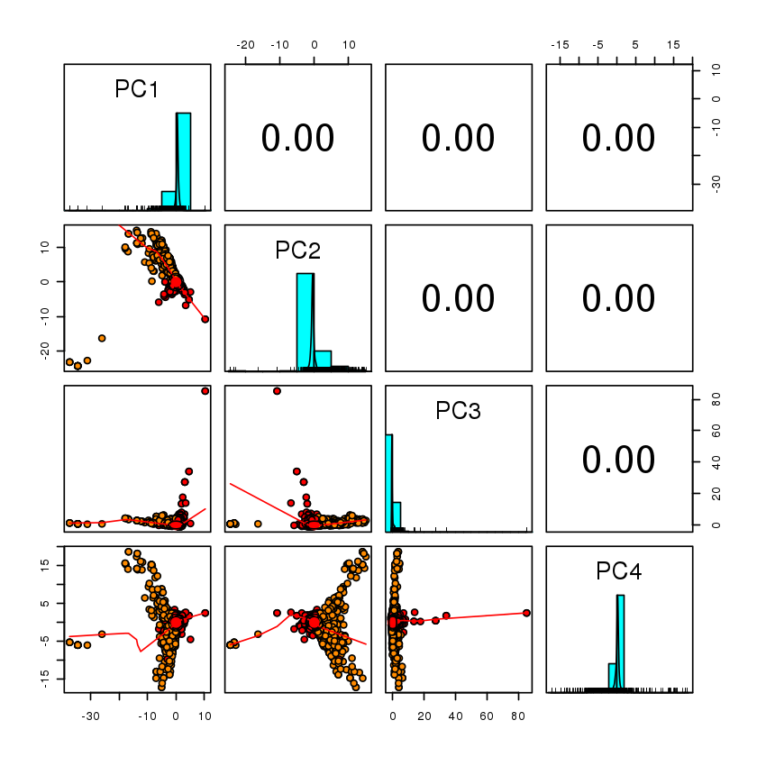

```r
# PCA: going back and forth between the original data and the rotated data
SMS.train.recover.full = exp(t(t(SMS.train.pca$x %*% t(SMS.train.pca$rotation)) * SMS.train.pca$scale + SMS.train.pca$center))
SMS.train.recover.pca = exp(t(t(SMS.train.pca.reduced %*% t(SMS.train.pca$rotation)) * SMS.train.pca$scale + SMS.train.pca$center))

# Setting the data in a data frame
SMS.train.pca.reduced.model = SMS.train.pca.reduced
SMS.train.pca.reduced.model = data.frame(SMS.train.pca.reduced, ham.spam.train.labels)

# plotting the classes in the training data set against the first 4 Principal Components
pairs.panels(SMS.train.pca$x[,1:4], pch=21, bg=rainbow(11)[unclass(ham.spam.train.labels)])
```

```r
training.pca = SMS.train.pca.reduced.model[,c(1,2,3,4)]
```

```r
training.pca
```

|  | PC1 | PC2 | PC3 | PC4 |
| --- | --- | --- | --- | --- |
| 3151 | 0.1623273 | -0.3896759 | -0.72876768 | 0.6104291772 |
| 1572 | 1.0215859 | -1.1555269 | 4.05657906 | 0.4888766983 |
| 3200 | 0.7070406 | -0.8290871 | -0.71952128 | 0.5952759108 |
| 1805 | 0.3153966 | -0.1166494 | -0.56667600 | -0.3637270149 |
| 1201 | -2.4277179 | -1.4842066 | -0.14202082 | -1.1339589610 |
| 534 | 0.2763362 | -0.3127209 | -0.54980376 | 0.2140892278 |
| 1769 | 0.3488081 | -0.2002827 | -0.48795000 | -0.0078760382 |
| 3796 | 0.3051001 | -0.4418744 | -0.35649598 | 0.7790183422 |
| 411 | -0.1829012 | 1.5011028 | 0.01747021 | -2.9144989085 |
| 2399 | 0.2763362 | -0.3127209 | -0.54980376 | 0.2140892278 |
| 3136 | 0.6759535 | -0.7143287 | -0.49488660 | 0.3581997642 |
| 4128 | -2.0151217 | 2.9845722 | -0.14034577 | -1.4862187837 |
| 342 | 0.4972645 | -0.4957797 | -0.51567341 | 0.2236625547 |
| 423 | -2.2508460 | 3.6690932 | 2.94831769 | 2.4594971980 |
| 364 | 0.2683147 | -0.2077135 | -0.58843978 | -0.0235029180 |
| 4029 | 0.4787728 | -0.3674161 | -0.48456545 | -0.0006508134 |
| 4931 | 0.6038279 | -0.2418830 | -0.55233054 | -0.6196033356 |
| 1447 | 0.2763362 | -0.3127209 | -0.54980376 | 0.2140892278 |
| 1273 | -0.1041815 | 0.8082250 | -0.46892361 | 1.1926626576 |
| 933 | -0.1226800 | 0.6651488 | 1.50775350 | -0.7200716506 |
| 3773 | 0.8684500 | -0.9244742 | -0.57061169 | 0.4816972379 |
| 5302 | 0.6103523 | -0.6129731 | -0.53288390 | 0.3635418783 |
| 1229 | 0.6376826 | -0.7391081 | -0.71189436 | 0.5728810581 |
| 4717 | 0.3312883 | -0.1674412 | 1.27646001 | -0.0465954148 |
| 967 | 0.9784671 | -0.9948954 | -0.67312098 | 0.5490131039 |
| 1208 | -3.9940471 | 3.2422771 | 0.57221967 | -0.1519732560 |
| 5393 | 0.5366033 | -0.7578184 | -0.48989836 | 0.4787354809 |
| 2378 | 1.0147652 | -1.0610360 | 1.17735347 | 0.5083262095 |
| 279 | 0.6797849 | -0.7152575 | -0.68205319 | 0.3661731151 |
| 553 | 0.5730251 | -0.5949369 | -0.52378026 | 0.3247667075 |
| ⋮ | ⋮ | ⋮ | ⋮ | ⋮ |
| 4140 | 0.169217702 | 0.2952334 | -0.3748181 | 0.48917658 |
| 117 | 3.096775621 | -3.0549353 | 27.3043622 | 0.48744074 |
| 736 | 0.705173263 | -0.7352863 | 1.2746565 | 0.33730536 |
| 103 | 1.011242315 | -1.0618158 | -0.9001238 | 0.62566954 |
| 1470 | 0.835622174 | -0.5293198 | -0.4170347 | 0.07179191 |
| 1410 | 0.533990777 | -0.6011927 | -0.6450057 | 0.39289858 |
| 3971 | 1.037713200 | -0.6745673 | -0.5427510 | -0.29708240 |
| 1521 | 0.473555263 | -0.5912880 | 1.4313429 | 0.11832337 |
| 1490 | 0.440982143 | -0.3986006 | -0.5295119 | 0.06559352 |
| 4766 | -0.608379870 | 0.4519821 | -0.5073726 | 0.55521506 |
| 2135 | 1.155400535 | -0.3358368 | 0.8262791 | -0.25637938 |
| 288 | 0.276336175 | -0.3127209 | -0.5498038 | 0.21408923 |
| 3010 | -0.114547796 | 1.0994151 | -0.5570213 | -2.52073862 |
| 1334 | 0.750470715 | -0.8340074 | -0.4306800 | 0.62467929 |
| 2683 | 0.466666040 | -0.5126354 | -0.6271341 | 0.35938301 |
| 3448 | 1.197408978 | -1.2637319 | -0.9399100 | 1.01703195 |
| 4585 | -2.764712161 | 7.6622213 | 1.5028748 | -12.24165691 |
| 4183 | 0.643594954 | -0.7297098 | -0.7107538 | 0.47210607 |
| 2034 | 0.754375187 | -0.6916829 | 3.3042398 | 0.34692862 |
| 4307 | 0.603563307 | -0.6311721 | -0.6216848 | 0.41278906 |
| 4605 | 1.059475375 | -1.1346422 | -0.6333285 | 0.49334717 |
| 1903 | 0.070973071 | -0.2783701 | -0.6663136 | 0.52101451 |
| 574 | 0.411657987 | -0.4556237 | -0.5951603 | 0.20232298 |
| 457 | 0.570869416 | -0.6195194 | -0.5718821 | 0.38280157 |
| 5152 | -0.002617177 | -0.1066144 | -0.5408380 | 0.23506742 |
| 819 | 0.463514924 | -0.4631558 | -0.5784267 | 0.26063944 |
| 3604 | 0.373938727 | -0.3771752 | -0.5484901 | 0.29766730 |
| 1301 | 0.610447577 | -0.5359233 | -0.3635620 | 0.12563916 |
| 4102 | 0.453888095 | -0.3953665 | -0.5132446 | 0.33765238 |
| 1651 | 0.356392450 | -0.3667279 | -0.5546346 | 0.17762892 |

```r
SMS.test.pca <- scale(as.data.frame(as.matrix(SMS.DTM.Freq.Terms.test)), SMS.train.pca$center, SMS.train.pca$scale) %*% SMS.train.pca$rotation
```

```r
SMS.test.pca.reduced <- SMS.test.pca
SMS.test.pca.reduced[,5:ncol(SMS.train.pca.reduced)] = 0
```

```r
SMS.test.pca.reduced.model = data.frame(SMS.test.pca.reduced)

testing.pca = SMS.test.pca.reduced.model[,c(1,2,3,4)]
```

```r
testing.pca
```

|  | PC1 | PC2 | PC3 | PC4 |
| --- | --- | --- | --- | --- |
| 3 | -2.75132799 | 6.4768588 | 0.90726450 | -7.25489807 |
| 7 | 0.56520704 | -0.4229668 | 0.20539495 | 0.77083095 |
| 9 | -10.96138187 | 5.7964261 | 1.49638613 | 6.49069937 |
| 11 | 0.94949498 | -0.9349716 | -0.69322291 | 0.68317512 |
| 13 | -5.75206496 | 8.5346912 | 1.99774636 | -0.61774019 |
| 14 | 0.93486648 | -0.5124374 | -0.47926519 | -0.72095284 |
| 16 | -0.65688698 | 2.3256023 | 0.06239654 | -4.68158997 |
| 18 | 0.60247640 | -0.4333913 | -0.49821438 | -0.13670030 |
| 20 | 0.17794617 | 0.2299591 | -0.35690668 | -0.76097909 |
| 21 | 0.36290773 | -0.4932655 | -0.54219964 | 0.11379112 |
| 22 | -0.21412575 | 0.3620507 | -0.30911875 | 0.75662528 |
| 23 | 0.54542279 | -0.5722480 | -0.42135662 | 0.13460366 |
| 28 | 1.40142643 | -1.5324188 | -0.56526293 | 0.93883540 |
| 35 | -0.60059287 | 2.5436772 | 0.17974575 | -3.82597534 |
| 43 | -2.98309903 | 5.5319971 | 0.44259657 | -4.05080734 |
| 44 | 0.27633618 | -0.3127209 | -0.54980376 | 0.21408923 |
| 45 | 0.89452094 | -0.8772311 | 1.15678562 | 0.33645687 |
| 48 | 0.49595387 | -0.5293733 | -0.59904043 | 0.35012859 |
| 53 | 0.84851490 | -0.8661326 | -0.55601371 | 0.31014445 |
| 54 | 1.21222764 | -0.8693292 | 0.97134212 | -0.06904832 |
| 60 | 0.27633618 | -0.3127209 | -0.54980376 | 0.21408923 |
| 68 | -2.74075449 | 3.2963084 | 0.37112738 | 2.51087952 |
| 73 | 0.45814005 | -0.2796146 | -0.49462032 | 0.17830469 |
| 77 | 0.51717911 | -0.5264506 | -0.69405535 | 0.24163770 |
| 80 | 0.66394115 | -0.7025608 | -0.69130626 | 0.47452979 |
| 81 | 0.07097307 | -0.2783701 | -0.66631360 | 0.52101451 |
| 83 | 0.47107522 | -0.5256004 | -0.57735100 | 0.32093510 |
| 84 | 0.63057613 | -0.6869131 | 1.24358776 | 0.25690860 |
| 85 | 0.31174760 | -0.1104006 | -0.57412773 | -0.26829031 |
| 86 | -0.58821211 | 1.0920759 | -0.43651607 | -1.06870132 |
| ⋮ | ⋮ | ⋮ | ⋮ | ⋮ |
| 5467 | 0.4555628 | -0.2372476 | -0.51086431 | -0.430082497 |
| 5470 | -1.1408955 | 2.4548212 | 0.13787144 | -1.533251456 |
| 5472 | 0.3996917 | -0.4773935 | -0.56837149 | 0.378222682 |
| 5474 | 0.3779142 | -0.4320385 | -0.64731718 | 0.331720974 |
| 5481 | 0.3919855 | -0.4211454 | -0.63794692 | 0.269014601 |
| 5482 | 0.8802194 | -0.8131633 | -0.09216047 | 0.129049997 |
| 5483 | 0.3424205 | -0.3558083 | -0.56496523 | 0.204417551 |
| 5487 | -2.3366827 | -2.2231384 | -0.42691966 | -0.579767299 |
| 5489 | 0.3924205 | -0.3242127 | -0.60012672 | -0.013002956 |
| 5492 | 0.4450412 | -0.5126137 | -0.55957171 | 0.332227029 |
| 5493 | 0.3331959 | -0.3640746 | -0.57726300 | 0.078763759 |
| 5495 | -0.8286366 | 2.6354827 | 0.03944159 | -3.352975191 |
| 5497 | 1.6743272 | -1.5306726 | -1.03559273 | 0.985535893 |
| 5498 | 1.4576622 | -1.4610772 | -0.06158405 | 0.740899213 |
| 5504 | -34.5212822 | -24.3736171 | 0.69120852 | -5.937429033 |
| 5508 | 0.6385907 | -0.6476520 | -0.27968332 | 0.525878609 |
| 5510 | 0.4370324 | -0.1855098 | -0.37942127 | -0.524325265 |
| 5513 | 0.6171600 | -0.6694430 | 1.20941958 | 0.341148913 |
| 5514 | 0.3510496 | -0.3612026 | -0.50876170 | -0.002317095 |
| 5517 | 0.4661505 | -0.5230617 | -0.66025811 | 0.374742119 |
| 5527 | -3.8121758 | 6.0532060 | 0.35299815 | 4.507872218 |
| 5536 | 0.5467460 | -0.1670192 | -0.49030369 | -0.698169470 |
| 5540 | -0.7211340 | 1.8887020 | -0.09627788 | -0.264265614 |
| 5544 | 0.6245735 | -0.7442798 | -0.62619164 | 0.597047541 |
| 5549 | 0.3828045 | -0.4190609 | -0.54444784 | 0.311413357 |
| 5551 | -0.5186233 | 0.3626446 | -0.40559155 | 1.128086851 |
| 5563 | 0.7081916 | -0.8784250 | -0.64677937 | 0.705223906 |
| 5566 | 0.7716291 | -0.9295362 | -0.69130275 | 0.700833599 |
| 5570 | -5.4897236 | 6.2078187 | 2.81190841 | 3.320833176 |
| 5573 | 0.6818120 | -0.1889282 | 0.08141994 | -0.693286278 |

```r
SMS.classifier.SVM.pca <- svm(ham.spam.train.labels ~., data=training.pca,type="C-classification",cost=10,kernel="linear")
class(SMS.classifier.SVM.pca)
summary(SMS.classifier.SVM.pca)
attributes(SMS.classifier.SVM.pca)
```

1. 'svm.formula'

2. 'svm'

```
Call:
svm(formula = ham.spam.train.labels ~ ., data = training.pca, type = "C-classification",
    cost = 10, kernel = "linear")


Parameters:
   SVM-Type:  C-classification
 SVM-Kernel:  linear
       cost:  10
      gamma:  0.25

Number of Support Vectors:  316

 ( 158 158 )


Number of Classes:  2

Levels:
 ham spam
```

**$names**

1. 'call'

2. 'type'

3. 'kernel'

4. 'cost'

5. 'degree'

6. 'gamma'

7. 'coef0'

8. 'nu'

9. 'epsilon'

10. 'sparse'

11. 'scaled'

12. 'x.scale'

13. 'y.scale'

14. 'nclasses'

15. 'levels'

16. 'tot.nSV'

17. 'nSV'

18. 'labels'

19. 'SV'

20. 'index'

21. 'rho'

22. 'compprob'

23. 'probA'

24. 'probB'

25. 'sigma'

26. 'coefs'

27. 'na.action'

28. 'fitted'

29. 'decision.values'

30. 'terms'

**$class**

1. 'svm.formula'

2. 'svm'

**ham**

1478

**spam**

195

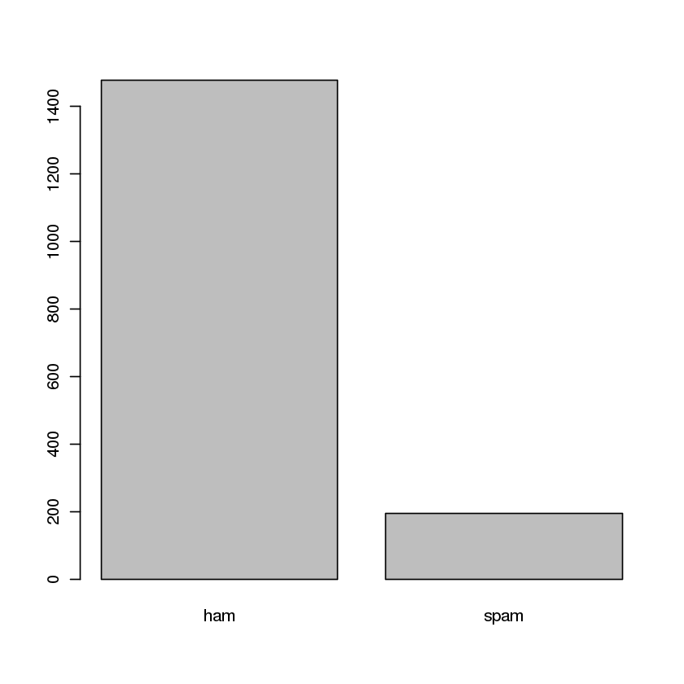

```r
SMS.test.pred.SVM.pca <- predict(SMS.classifier.SVM.pca,testing.pca)
summary(SMS.test.pred.SVM.pca)   # provide a summary of the predicted values
plot(SMS.test.pred.SVM.pca)   # ... and a plot
```

```r
(confusion.matrix.pca = table(pred = SMS.test.pred.SVM.pca, true = ham.spam.test.labels))
classAgreement(confusion.matrix.pca,match.names=TRUE)    # some metrics to determine how good the classifier is at predicting data
```

```
      true
pred    ham spam
  ham  1438   40
  spam    9  186
```

**$diag**

0.97071129707113

**$kappa**

0.866962136862963

**$rand**

0.943104242157314

**$crand**

0.834373879759884

```r
# tuning for C
tuning.pca <- tune(svm, train.x=training.pca, train.y=ham.spam.train.labels, kernel="linear", ranges=list(cost=10^(-3:3)))
print(tuning.pca)    # optimal parameters
```

```
Parameter tuning of ‘svm’:

- sampling method: 10-fold cross validation

- best parameters:
 cost
   10

- best performance: 0.0302492
```

Back to top

## EXERCISES <a name=exer></a>

- Play with the various parameters in the NB and SVM models
- Can you create a classifier for Fake News/Real News (the code to import the data is commented out below)

```r
# Import text data
#real_news <- read.csv(file="Data/fake_or_real_news1_utf8.csv", header=TRUE, sep=",", stringsAsFactors=FALSE)
#fake_news <- read.csv(file="Data/fake_or_real_news2_utf8.csv", header=TRUE, sep=",", stringsAsFactors=FALSE)

# View the structure of recaps
#str(real_news)
#str(fake_news)
```